# STA4026S CA1

Antony Fleischer

25/08/2021

## Question 1

### a)

After dividing the mealie data into training and test sets using an 80/20 split, a decision tree was fit to the data using all features.

```r
set.seed(13)
index <- sample(1:nrow(mealie), 0.8*nrow(mealie))
train <- mealie[index,]
test <- mealie[-index,]
tree.mealie <- tree(quality ~ ., data=train)
```

The feature space has been split into 16, with each split chosen because it causes the greatest reduction in the Gini index - the defaut measure of node purity. Additionally, the tree was not split further because a stopping criteria was reached - either the nodes were too small or the within-node deviance was not large enough. The training misclassification rate shows that the tree does not model the data perfectly, as 58 of the 1000 observations are incorrectly categorised. This is acceptable, as a perfect training data classifier would not predict new observations accurately. Lastly, only 4 of the 5 explanatory variables were used to split the training data. This means that at no point in the recursive binary splitting process did a split on ‘height’ provide the largest redution in the Gini index.

```r
Classification tree:
tree(formula = quality ~ ., data=train)
Variables actually used in tree construction:
[1] "latitude"  "count"     "longitude" "pests"
Number of terminal nodes:  16
Residual mean deviance:  0.3035 = 298.7 / 984
Misclassification error rate: 0.058 = 58 / 1000
```

### b)

As shown in `?tree.control`, a tree that fits the data perfectly can be modelled by setting the minimum within-node deviance (mindev) to 0, and minimum node size to 2. By relaxing these parameters, the tree is able to continue splitting until all of the nodes are the homogenous.

```r
set.seed(13)
tree.mealie.relaxed <- tree(quality~ ., data=train, control=tree.control(nrow(train), minsize=2, mindev=0))
```

The misclassification rate of 0% shows that each node is correctly classified, and it can be inferred that each node is homogenous. Conversely to the default tree trained earlier (`tree.mealie`), all of the explanatory variables were used to split the feature space. The tree is also extremely large, with 45 terminal nodes.

```r
Classification tree:
tree(formula = quality ~ ., data = train, control = tree.control(nrow(train),
    minsize = 2, mindev = 0))
Number of terminal nodes:  45
Residual mean deviance:  0 = 0 / 955
Misclassification error rate: 0 = 0 / 1000
```

### c)

Using the `which.min` function, R returns a sub-tree with 45 terminal nodes as the tree with the lowest cross-validation error.

```r
set.seed(13)
cv.mealie<- cv.tree(tree.mealie.relaxed, FUN=prune.misclass, K = 10)
cv.mealie$size[which.min(cv.mealie$dev)]
```

```
## [1] 45
```

However, upon manual inspection of the cross-validations errors and sub-tree sizes, it is evident that a subtree of size 24 produces the same cross-validation error as the 45-node subtree. The reason the `which.min` functions returns 45 is because it finds the first occurence of a minimum value, and the tree size decreases from 45.

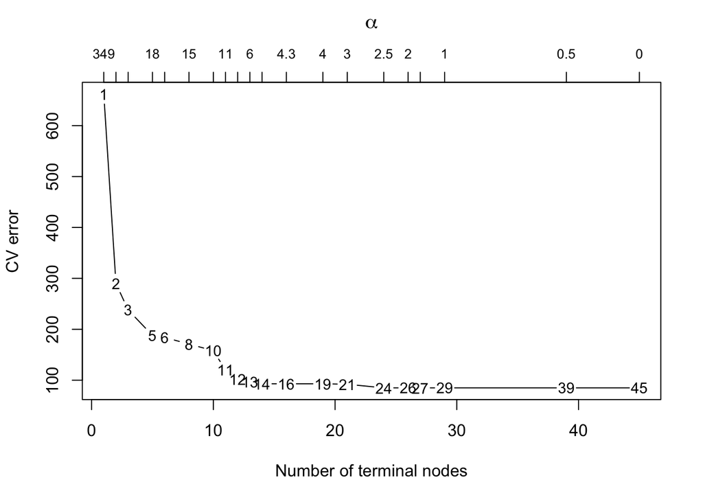

Although sub-trees with more terminal nodes produce lower misclassification error rates than a 24-node tree, I decided to prune the tree to 24 nodes to reduce model variance and increase interperability. Resultingly, the tree no longer perfectly models the training data, and so the bias of the model has increased. This reduces overfitting to some extent and, as a result, the pruned tree may be a better predictor on the test subset.

```r
pr.mealie <- prune.misclass(tree.mealie.relaxed, best = 24)
```

The `snip.tree` function shows the nodes that are the roots of the sub-trees that are to be pruned. The tree is nearly half the size of the full 45-node tree, and has a misclassification rate of 2.3%. Once again, the ‘height’ variable has not been used to split the feature space, as it does not provide the highest reduction in the Gini idex for any split in a 24-node tree.

```r
Classification tree:
snip.tree(tree = tree.mealie.relaxed, nodes = c(44L, 87L, 12L,
15L, 40L, 90L, 42L, 86L, 58L))
Variables actually used in tree construction:
[1] "latitude"  "count"     "longitude" "pests"
Number of terminal nodes:  24
Residual mean deviance:  0.1742 = 170 / 976
Misclassification error rate: 0.023 = 23 / 1000
```

### d)

The default tree from part a), the homogenous-leaf tree and the pruned tree were used to make predictions on the test set. An example of how the testing misclassification rate was calcualted is shown below.

```r
set.seed(13)
yhat_default <- predict(tree.mealie, test, type = 'class')
(c_mat <- table(yhat_default, test$quality))
accuracy_default <- sum(diag(c_mat))/nrow(test)*100 #Classification accuracy for default tree
misclass_default <- c("Test Misclassifcation Rate - Default:",round(1 - sum(diag(c_mat))/nrow(test), 3))
```

```r
Train Misclassification Rate - Default: 0.058 = 58 / 1000
Test Misclassifcation Rate - Default: 0.064
Train Misclassification Rate - Homogenous: 0 = 0 / 1000
Test Misclassifcation Rate - Homogenous: 0.02
Train Misclassification Rate - Prune: 0.023 = 23 / 1000
Test Misclassifcation Rate - Prune: 0.036
```

## Question 2

### a)

```
##      |      Out-of-bag   |
## Tree |      MSE  %Var(y) |
##   50 |    9.897     8.65 |
##  100 |    9.607     8.39 |
##  150 |    9.389     8.20 |
##  200 |     9.32     8.14 |
##  250 |    9.269     8.10 |
##  300 |    9.298     8.12 |
##  350 |     9.25     8.08 |
##  400 |     9.22     8.05 |
##  450 |    9.208     8.04 |
##  500 |    9.219     8.05 |
```

```
##
## Call:
##  randomForest(formula = total_UPDRS ~ ., data = parkinsons, mtry = ncol(parkinsons) -      1, ntree = 500, importance = TRUE, do.trace = 50, na.action = na.exclude)
##                Type of random forest: regression
##                      Number of trees: 500
## No. of variables tried at each split: 18
##
##           Mean of squared residuals: 9.219409
##                     % Var explained: 91.95
```

```
##      |      Out-of-bag   |
## Tree |      MSE  %Var(y) |
##   50 |    20.64    18.03 |
##  100 |    20.15    17.60 |
##  150 |    19.69    17.20 |
##  200 |    19.36    16.91 |
##  250 |    19.17    16.74 |
##  300 |    19.12    16.70 |
##  350 |     19.2    16.77 |
##  400 |    19.14    16.72 |
##  450 |       19    16.60 |
##  500 |    18.93    16.54 |
```

```
##
## Call:
##  randomForest(formula = total_UPDRS ~ ., data = parkinsons, ntree = 500,      importance = TRUE, do.trace = 50, na.action = na.exclude)
##                Type of random forest: regression
##                      Number of trees: 500
## No. of variables tried at each split: 6
##
##           Mean of squared residuals: 18.93297
##                     % Var explained: 83.46
```

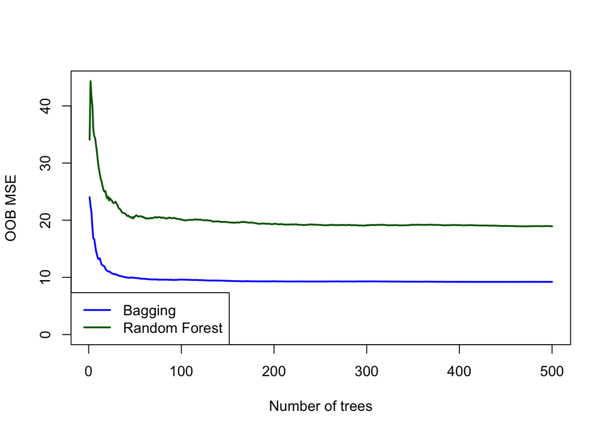